# Negativas de acesso a informação no governo Federal

Órgãos e entidades do poder Executivo - janeiro de 2015 até 2021

```r
library(tidyverse)
library(lubridate)
library(glue)
library(here)
library(ggtext)
library(patchwork)
library(kableExtra)
library(hrbrthemes)
library(tidytext)
library(wordcloud)
source(here("src/5-funcao-limpando-texto.R"))
```

```r
set.seed(1014)

knitr::knit_hooks$set(inline = function(x) prettyNum(x, big.mark = ".", decimal.mark = ","))

options(
  digits = 1,
  scipen = 999,
  OutDec = ",",
  knitr.kable.NA = "",
  radian.auto_match = FALSE
)

Sys.setenv(LANGUAGE = "pt-br")
Sys.setlocale("LC_TIME", "pt_BR")
```

```
#> [1] ""
```

```r
# helper
`%notin%` <- function(x, y) !(x %in% y)
```

```r
source(here("src/0-paleta-de-cores.R"), encoding = "UTF-8")

theme_set(theme_minimal())

theme_update(
  panel.grid.minor = element_blank(),
  panel.background = element_rect(fill = "gray97", color = "transparent")
)
```

```r
pedidos_cgu <- "dados/load/rds/pedidos-cgu.rds" %>%
  here() %>%
  readRDS() %>%
  rename(orgao = orgaodestinatario) %>%
  filter(decisao %notin% c(
    "Pergunta Duplicada/Repetida",
    "Não se trata de solicitação de informação"
  ))

pedidos_clean <- "dados/load/rds/pedidos-clean.rds" %>%
  here() %>%
  readRDS()

recursos_clean <- "dados/load/rds/recursos-clean.rds" %>%
  here() %>%
  readRDS()
```

```r
pedidos_clean <- pedidos_clean %>%
  mutate(
    usa_lgpd_pedido_resumido = str_detect(resumo_solicitacao_clean, "LGPD"),
    usa_lgpd_pedido = str_detect(detalhamento_solicitacao_clean, "LGPD"),
    usa_lgpd_resposta = str_detect(resposta_clean, "LGPD")
  )

lgpd <- pedidos_cgu %>%
  select(
    id_pedido, orgao, data_registro,
    resumo_solicitacao, detalhamento_solicitacao,
    resposta, decisao, assunto_pedido
  ) %>%
  left_join(pedidos_clean) %>%
  mutate(
    usa_lgpd_assunto = assunto_pedido == "Dados Pessoais - LGPD",
    usa_lgpd_pedido_resumido = replace_na(usa_lgpd_pedido_resumido, FALSE),
    usa_lgpd = !(!usa_lgpd_pedido_resumido &
                  !usa_lgpd_pedido &
                  !usa_lgpd_resposta &
                  !usa_lgpd_assunto)
    )
```

### Evolução de uso da LGPD em pedidos LAI

O gráfico abaixo mostra a evolução dos pedidos onde alguma menção à LGPD foi detectada tanto no pedido quanto na resposta.

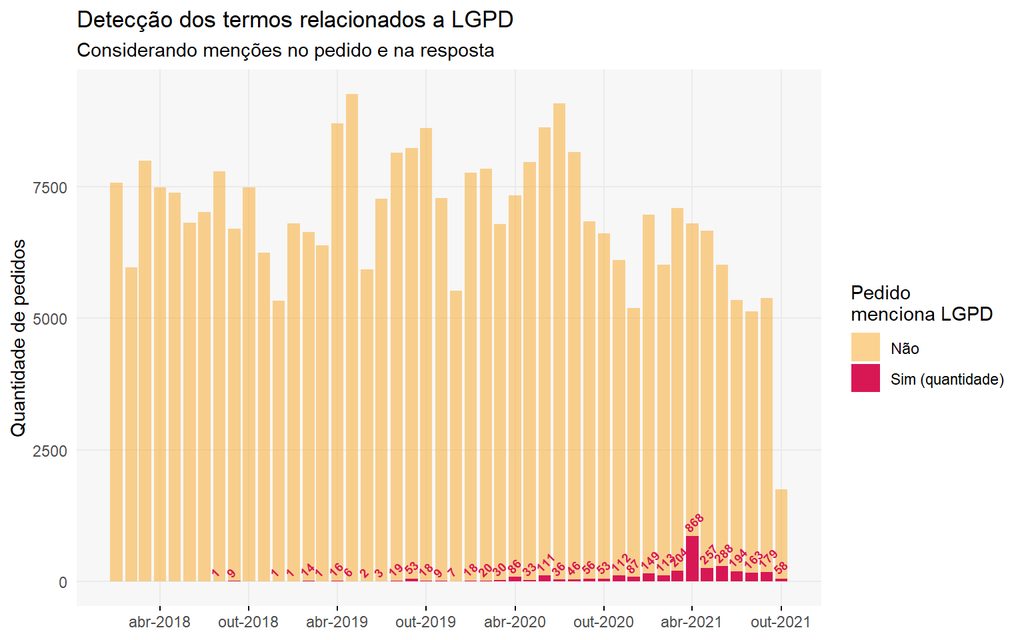

```r
lgpd %>%
  filter(year(data_registro) >= 2018) %>%
  count(data_registro, usa_lgpd) %>%
  mutate(usa_lgpd = if_else(usa_lgpd, "Sim (quantidade)", "Não")) %>%
  ggplot(aes(x = data_registro, y = n, fill = reorder(usa_lgpd, -n))) +
  geom_col() +
  geom_text(
    data = . %>%
      add_count(data_registro, wt = n) %>%
      filter(usa_lgpd == "Não") %>%
      mutate(nn - n) %>%
      filter(`nn - n` > 0),
    aes(
      y = `nn - n`,
      label = `nn - n`,
    ),
    color = cores_aep[["rosa"]],
    vjust = -.5,
    hjust = 0,
    size = 2.5,
    fontface = "bold",
    angle = 45
  ) +
  labs(
    title = "Detecção dos termos relacionados a LGPD",
    subtitle = "Considerando menções no pedido e na resposta",
    x = NULL,
    y = "Quantidade de pedidos",
    fill = "Pedido\nmenciona LGPD"
  ) +
  scale_fill_manual(values = c(alpha(cores_aep[["laranja"]], .5),
                               cores_aep[["rosa"]])) +
  scale_x_date(date_breaks = "6 months", date_labels = "%b-%Y") +
  theme(axis.ticks.x = element_line())
```

```r
lgpd_counts <- lgpd %>%
  select(data_registro, where(is.logical)) %>%
  filter(usa_lgpd) %>%
  mutate(
    data_registro,
    mencao_lgpd = case_when(
      !usa_lgpd_assunto &
        !usa_lgpd_pedido &
        !usa_lgpd_pedido_resumido ~ str_glue(
          "Solicitante não menciona LGPD em pedido,",
          "\nórgão menciona na resposta"
        ),
      TRUE ~ "Solicitante menciona LGPD no pedido ou assunto do pedido"
    )
  ) %>%
  count(data_registro, mencao_lgpd)
```

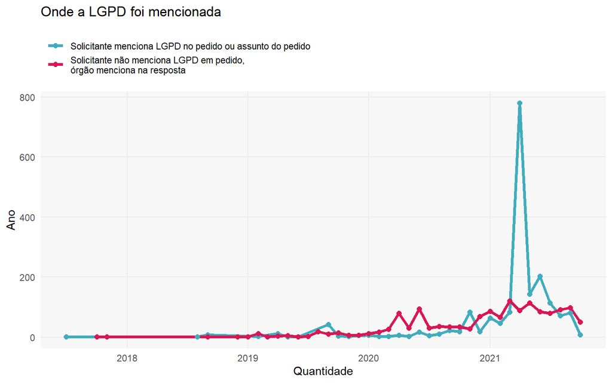

```r
lgpd_counts %>%
  ggplot(aes(x = data_registro, y = n, color = reorder(mencao_lgpd, -n))) +
  geom_line(size = 1.3) +
  geom_point(size = 2) +
  scale_color_manual(values = c(cores_tb[["azul"]], cores_aep[["rosa"]])) +
  labs(title = "Onde a LGPD foi mencionada",
       color = NULL,
       x = "Quantidade",
       y = "Ano"
       ) +
  theme(legend.position = "top",
        legend.direction = "vertical",
        legend.justification = "left")
```

Analisando ano a ano, agregando os meses, as solicitações respondidas com menções à LGPD, praticamente dobrou em 2021 em relação à 2020.

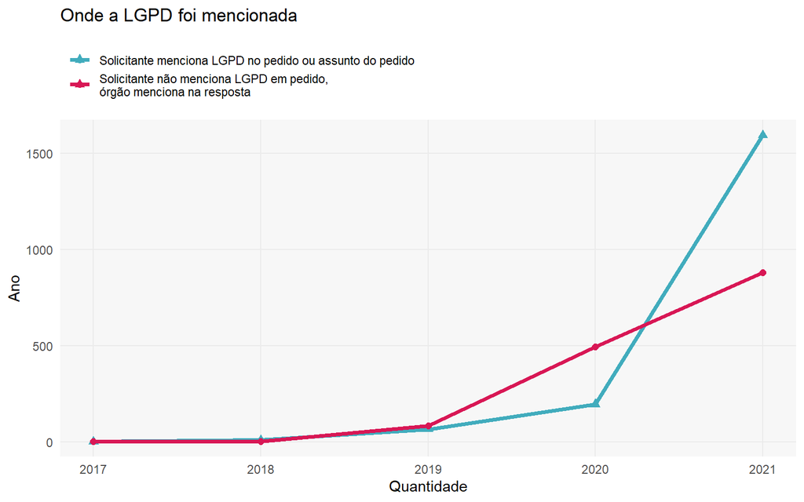

```r
lgpd_counts %>%
  count(ano = year(data_registro), mencao_lgpd,
        wt = n, name = "n") %>%
  ggplot(aes(x = ano, y = n, color = mencao_lgpd)) +
  geom_line(
    data = . %>%
      filter(mencao_lgpd != str_glue("Solicitante não menciona LGPD em pedido,",
                                     "\nórgão menciona na resposta")),
    size = 1.3) +
  geom_point(
    data = . %>%
      filter(mencao_lgpd != str_glue("Solicitante não menciona LGPD em pedido,",
                                     "\nórgão menciona na resposta")),
    size = 2.3, shape = 17) +
  geom_line(
    data = . %>%
      filter(mencao_lgpd == str_glue("Solicitante não menciona LGPD em pedido,",
                                     "\nórgão menciona na resposta")),
    size = 1.3) +
  geom_point(
    data = . %>%
      filter(mencao_lgpd == str_glue("Solicitante não menciona LGPD em pedido,",
                                     "\nórgão menciona na resposta")),
    size = 2) +
  scale_color_manual(values = c(cores_tb[["azul"]], cores_aep[["rosa"]])) +
  labs(title = "Onde a LGPD foi mencionada",
       color = NULL,
       x = "Quantidade",
       y = "Ano"
       ) +
  theme(
    legend.position = "top",
    legend.direction = "vertical",
    legend.justification = "left"
  )
```

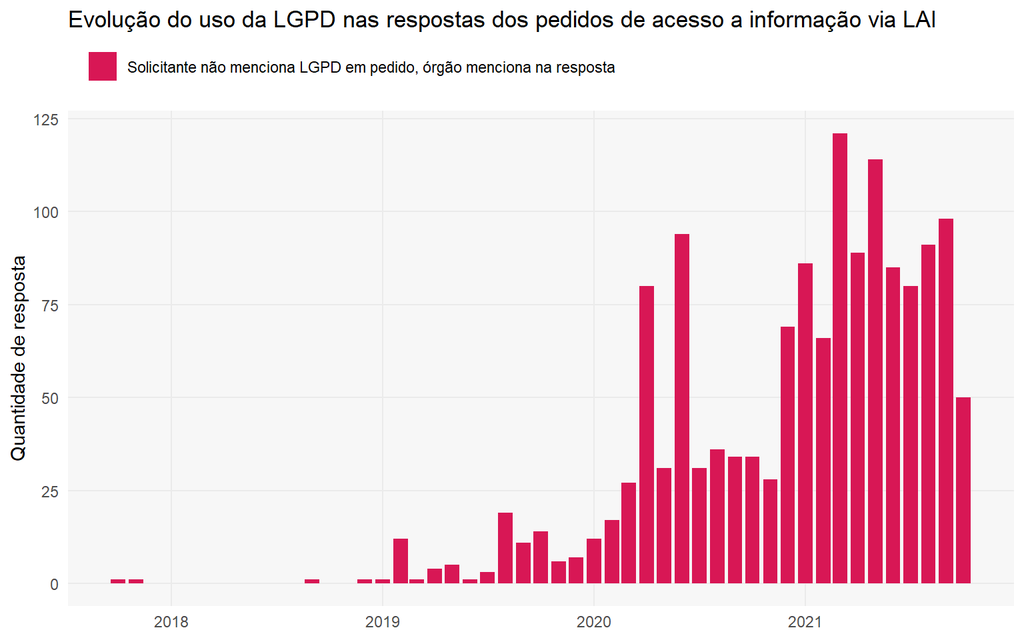

```r
lgpd_counts %>%
  filter(str_detect(mencao_lgpd, "Solicitante não menciona LGPD em pedido")) %>%
  mutate(mencao_lgpd = str_replace(mencao_lgpd, "\\n", " ")) %>%
  ggplot(aes(x = data_registro, y = n, fill = mencao_lgpd)) +
  geom_col() +
  scale_fill_manual(values = cores_aep[["rosa"]]) +
  labs(
    y = "Quantidade de resposta",
    x = NULL,
    title = str_glue(
      "Evolução do uso da LGPD nas respostas dos ",
      "pedidos de acesso a informação via LAI"
    ),
    fill = NULL
  ) +
  theme(
    legend.justification = "left",
    legend.position = "top"
  )
```

### Uso da LGPD pelos órgãos para responder uma demanda qualquer via LAI

Quantidade de vezes que órgãos citaram LGPD para responder algum pedido:

**O termo LGPD foi detectado na resposta do pedido, mas o solicitante não menciona o assunto no pedido (o termo não é detectado no pedido).**

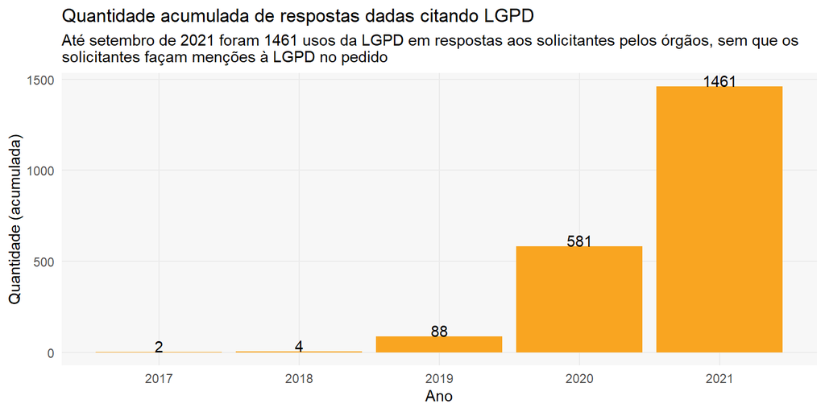

```r
qt_lgpd <- lgpd %>%
  filter(
    usa_lgpd_resposta &
     !usa_lgpd_pedido &
     !usa_lgpd_pedido_resumido &
     assunto_pedido != "Dados Pessoais - LGPD"
  ) %>%
  count(ano = year(data_registro), usa_lgpd_resposta, usa_lgpd_pedido)

qt_lgpd %>%
  ggplot(aes(x = ano, y = cumsum(n))) +
  geom_col(fill = cores_aep[["laranja"]]) +
  geom_text(aes(label = cumsum(n)), vjust = 0) +
  labs(
    x = "Ano",
    y = "Quantidade (acumulada)",
    title = "Quantidade acumulada de respostas dadas citando LGPD",
    subtitle = str_glue(
      "Até setembro de 2021 foram {sum(qt_lgpd$n)} ",
      "usos da LGPD em respostas aos solicitantes pelos órgãos, sem que os \n",
      "solicitantes façam menções à LGPD no pedido"
  ))
```

### Assuntos onde o órgão mencionou a LGPD

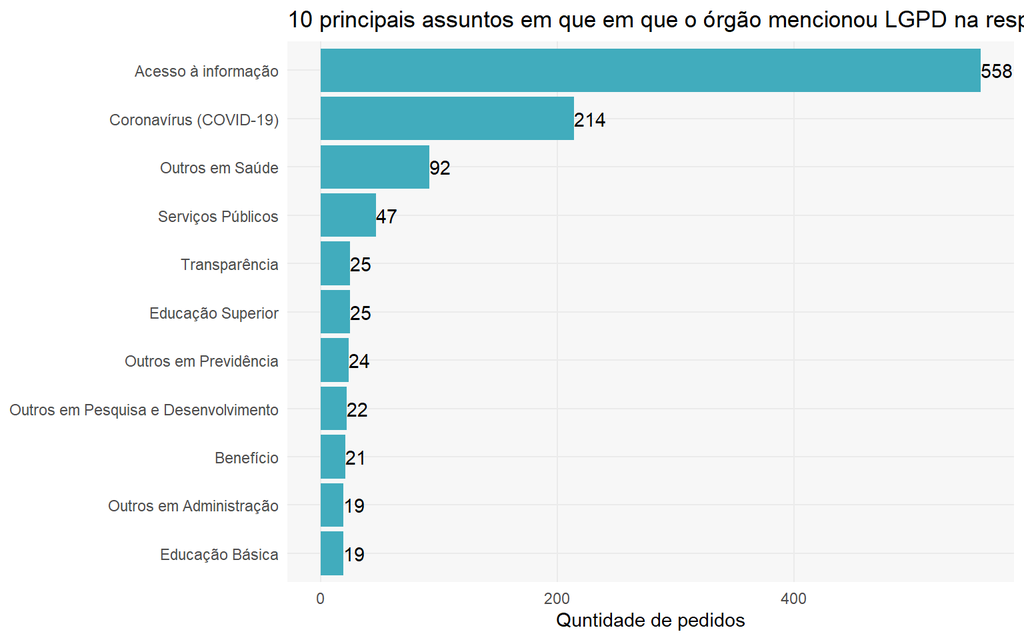

```r
lgpd %>%
  filter(
    usa_lgpd_resposta &
     !usa_lgpd_pedido &
     !usa_lgpd_pedido_resumido &
     assunto_pedido != "Dados Pessoais - LGPD"
  ) %>%
  count(assunto_pedido, sort = T) %>%
  slice_max(n = 10, order_by = n) %>%
  ggplot(aes(x = reorder(assunto_pedido, n), y = n)) +
  geom_col(fill = cores_tb[["azul"]]) +
  geom_text(aes(label = n), hjust = 0) +
  labs(
    title = "10 principais assuntos em que em que o órgão mencionou LGPD na resposta",
    y = "Quntidade de pedidos",
    x = NULL
  ) +
  coord_flip()
```

### Decisões quando órgão menciona LGPD

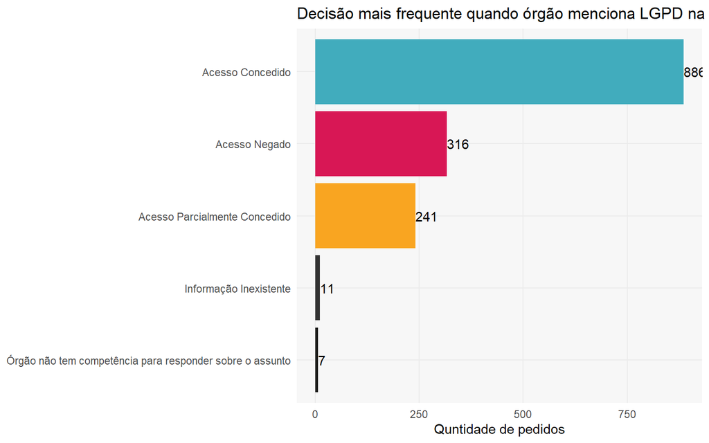

```r
lgpd %>%
  filter(
    usa_lgpd_resposta &
     !usa_lgpd_pedido &
     !usa_lgpd_pedido_resumido &
     assunto_pedido != "Dados Pessoais - LGPD"
  ) %>%
  count(decisao, sort = T) %>%
  slice_max(n = 10, order_by = n) %>%
  ggplot(aes(x = reorder(decisao, n), y = n)) +
  geom_col(aes(fill = decisao), show.legend = F) +
  geom_text(aes(label = n), hjust = 0) +
  labs(
    title = "Decisão mais frequente quando órgão menciona LGPD na resposta",
    y = "Quntidade de pedidos",
    x = NULL
  ) +
  scale_fill_manual(values = cores_decisao2) +
  coord_flip()
```

### Órgãos que mais usaram LGPD em respostas

> O gráfico abaixo mostra os órgãos que mencionaram a LGPD, **considerando somente pedidos em que o solicitante não menciona ou não faz referência à LGPD no pedido**.

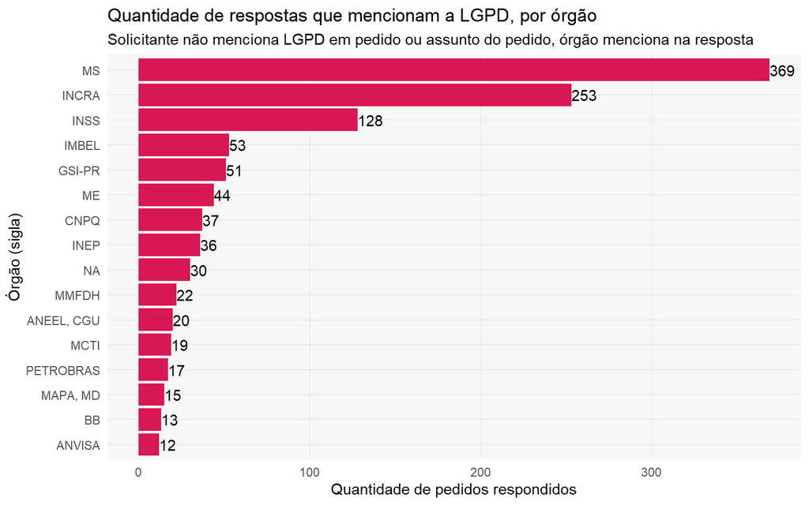

```r
lgpd %>%
  filter(
    usa_lgpd_resposta &
     !usa_lgpd_pedido &
     !usa_lgpd_pedido_resumido &
     assunto_pedido != "Dados Pessoais - LGPD"
  ) %>%
  count(sigla = str_extract(orgao, "^[:upper:]+(?= )|^GSI-PR"), sort = T) %>%
  group_by(n) %>%
  nest() %>%
  ungroup() %>%
  mutate(
    sigla = map(data, pull, sigla),
    sigla = paste(sigla),
    sigla = str_remove_all(sigla, "^c\\(|\\\"|\\)" ),
    sigla = str_wrap(sigla, 100)
  ) %>%
  filter(n > 10) %>%
  ggplot(aes(x = reorder(sigla, n), y = n)) +
  geom_col(fill = cores_aep[["rosa"]]) +
  geom_text(aes(label = n), hjust = 0) +
  coord_flip() +
  labs(
    title = "Quantidade de respostas que mencionam a LGPD, por órgão",
    subtitle = str_glue(
      "Solicitante não menciona LGPD em pedido ou assunto do pedido, ",
      "órgão menciona na resposta"
    ),
    x = "Órgão (sigla)",
    y = "Quantidade de pedidos respondidos"
  )
```

#### MS - Ministério da Saúde

```r
plot_historico_mencao_lgpd <- function(df, nome_orgao) {
  df <- df %>%
    filter(orgao == nome_orgao) %>%
    filter(
      usa_lgpd_resposta &
       !usa_lgpd_pedido &
       !usa_lgpd_pedido_resumido &
       assunto_pedido != "Dados Pessoais - LGPD"
    )  %>%
    count(data_registro, orgao)

  df %>%
    ggplot(aes(x = data_registro, y = n)) +
    geom_col(fill = cores_aep[["rosa"]]) +
    scale_x_date(date_labels = "%b-%Y") +
    labs(
      title = str_glue("{unique(df$orgao)}"),
      subtitle = "Menções à LGPD apenas na resposta e ausentes nos pedidos",
      x = NULL,
      y = "Quantidade de pedidos respondidos"
    )
}

plot_assuntos_mencao_lgpd <- function(df, nome_orgao) {
  df <- df %>%
    filter(orgao == nome_orgao) %>%
    filter(
      usa_lgpd_resposta &
        !usa_lgpd_pedido &
        !usa_lgpd_pedido_resumido &
        assunto_pedido != "Dados Pessoais - LGPD"
    ) %>%
  count(assunto_pedido = str_wrap(assunto_pedido, 30), orgao, sort = T) %>%
  filter(row_number() <= 10)

  df %>%
    ggplot(aes(y = n, x = reorder(assunto_pedido, n))) +
    geom_col(fill = cores_aep[["laranja"]]) +
    geom_text(aes(label = n), hjust = 0) +
    coord_flip() +
    labs(
      title = str_glue("Principais assuntos - {unique(df$orgao)}"),
      subtitle = "Assuntos abordados que levaram o órgão a responder com menção a LGPD",
      x = NULL,
      y = "Quantidade de pedidos"
    )
}

plot_decisoes_mencao_lgpd <- function(df, nome_orgao) {
  df <- df %>%
    filter(orgao == nome_orgao) %>%
    filter(
      usa_lgpd_resposta &
        !usa_lgpd_pedido &
        !usa_lgpd_pedido_resumido &
        assunto_pedido != "Dados Pessoais - LGPD"
    ) %>%
  count(orgao, data_registro, decisao = str_wrap(decisao, 25), sort = T)

  cores_decisao <- str_wrap(cores_decisao[-c(2, 5)], 25)

  df %>%
    ggplot(aes(x = data_registro, y = n, color = decisao)) +
    geom_line(size = .8) +
    scale_color_manual(values = cores_decisao) +
    scale_x_date(date_labels = "%b-%Y") +
    labs(
      title = str_glue("{unique(df$orgao)}"),
      subtitle = "Menção à LGPD e decisão sobre acesso",
      x = NULL,
      y = "Quantidade"
    )
}

plot_wordcloud_mencao_lgpd <- function(df, nome_orgao) {
  df <- df %>%
    filter(orgao == nome_orgao) %>%
    filter(
      usa_lgpd_resposta &
       !usa_lgpd_pedido &
       !usa_lgpd_pedido_resumido &
       assunto_pedido != "Dados Pessoais - LGPD"
    ) %>%
    select(id_pedido, detalhamento_solicitacao_clean) %>%
    unnest_tokens(word, detalhamento_solicitacao_clean) %>%
    anti_join(stopwords) %>%
    mutate(
        word = str_extract(word, "[a-z']+"),
        word = if_else(word == "urltag", "link-url", word)
    ) %>%
    filter(!str_count(word) %in% c(1, 2)) %>%
    count(word, sort = T)

  df %>%
    with(
      wordcloud(
        word,
        n,
        max.words = 150,
        random.order = F,
        random.color = F,
        main = title,
        colors = c(
          cores_tb[["cinza_claro"]],
          cores_aep[["laranja"]],
          cores_aep[["rosa"]],
          cores_tb[["azul"]]
        )
      )
    )

}
```

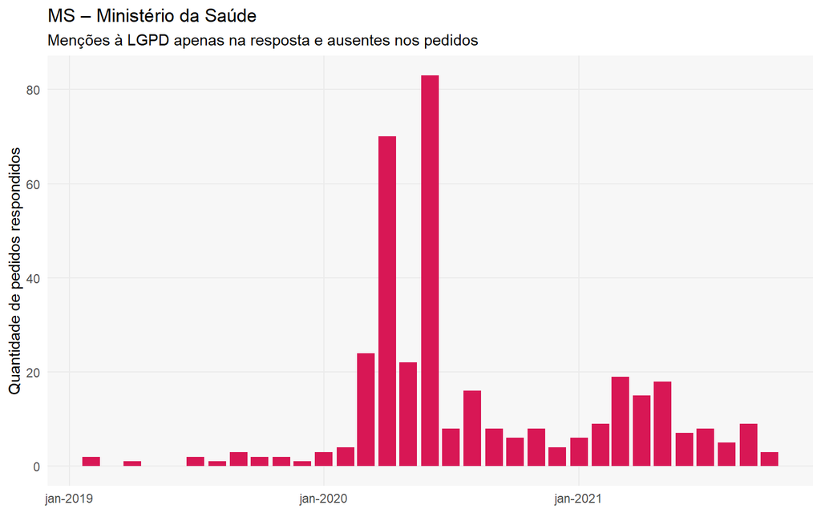

```r
plot_historico_mencao_lgpd(lgpd, "MS – Ministério da Saúde")
```

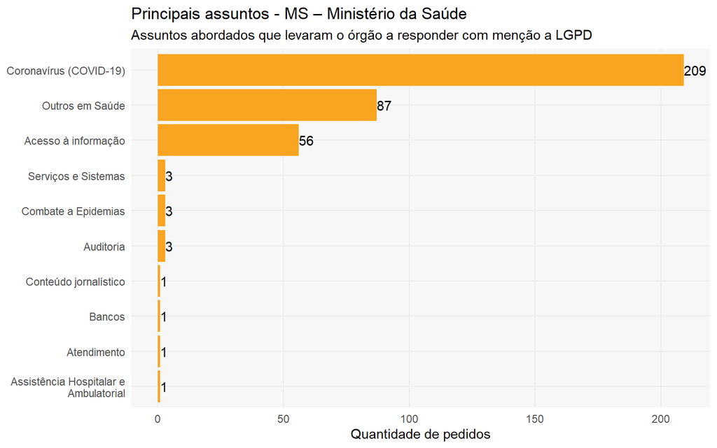

```r
plot_assuntos_mencao_lgpd(lgpd, "MS – Ministério da Saúde")
```

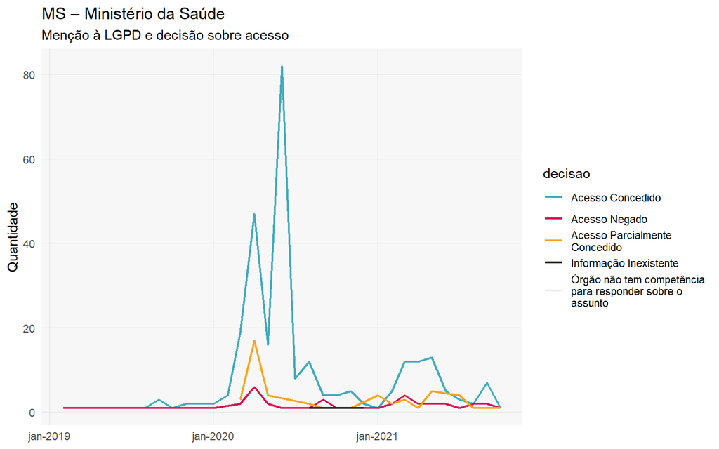

```r
plot_decisoes_mencao_lgpd(lgpd, "MS – Ministério da Saúde")
```

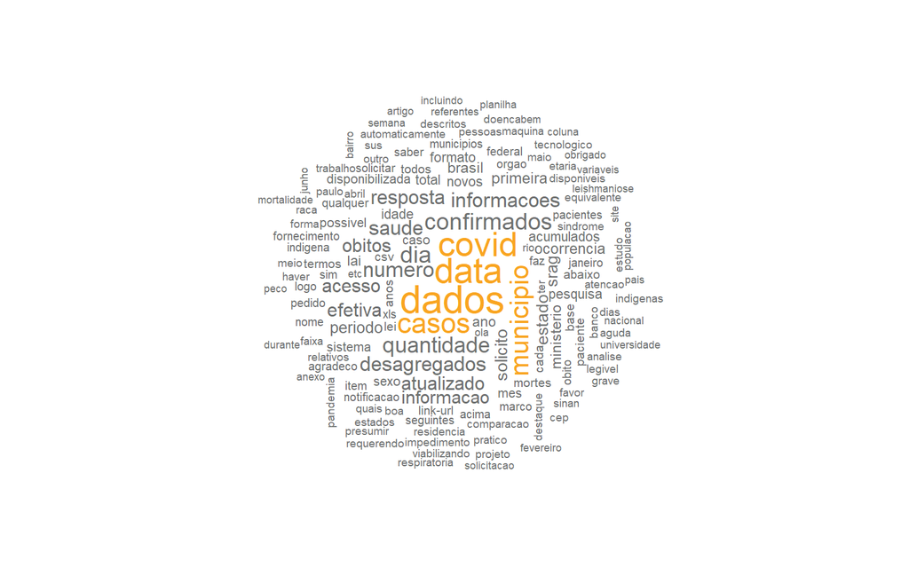

```r
plot_wordcloud_mencao_lgpd(lgpd, "MS – Ministério da Saúde")
```

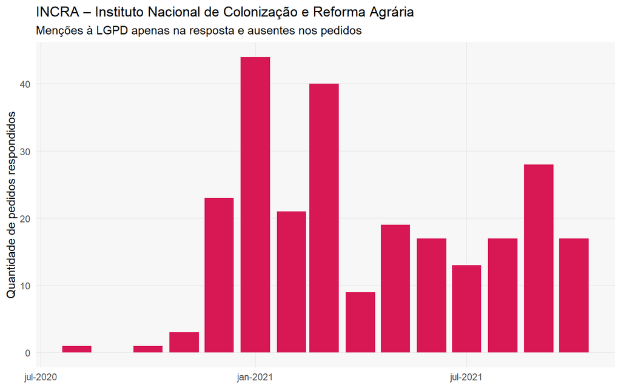

```r
plot_historico_mencao_lgpd(lgpd, "INCRA – Instituto Nacional de Colonização e Reforma Agrária")
```

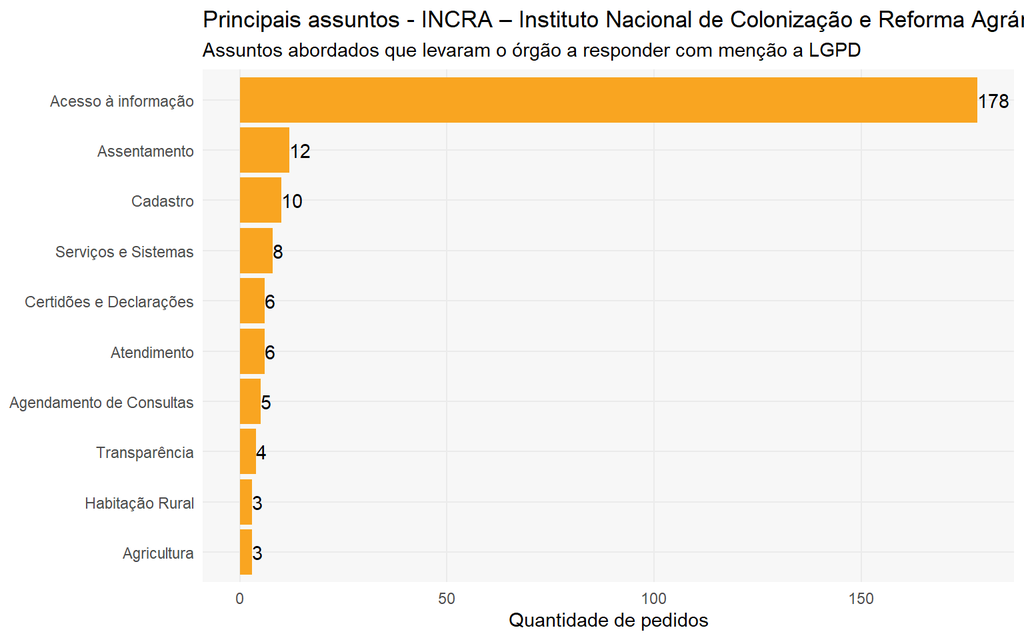

```r
plot_assuntos_mencao_lgpd(lgpd, "INCRA – Instituto Nacional de Colonização e Reforma Agrária")
```

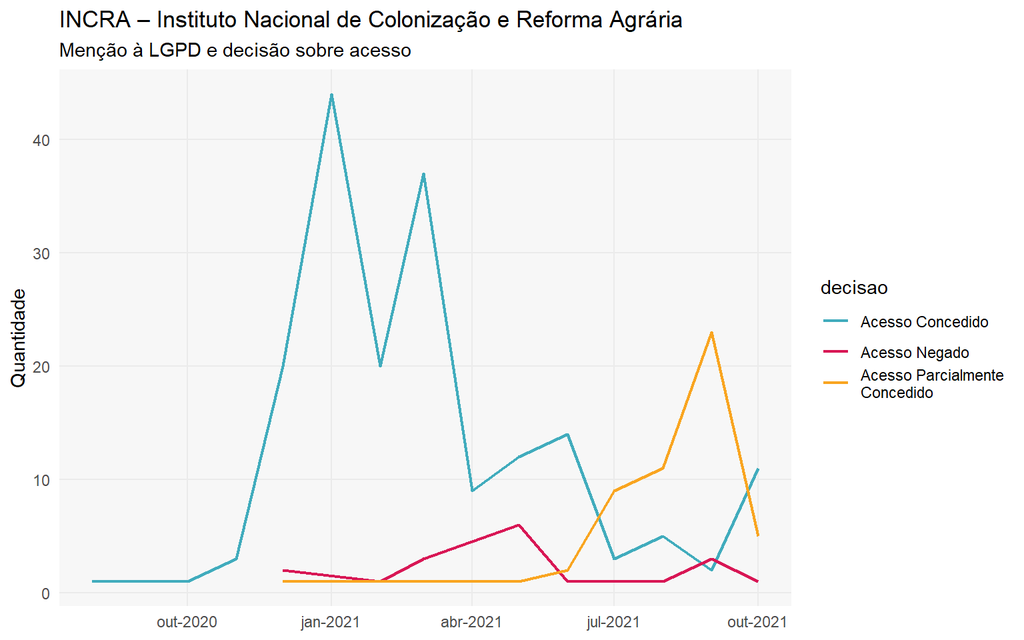

```r
plot_decisoes_mencao_lgpd(lgpd, "INCRA – Instituto Nacional de Colonização e Reforma Agrária")
```

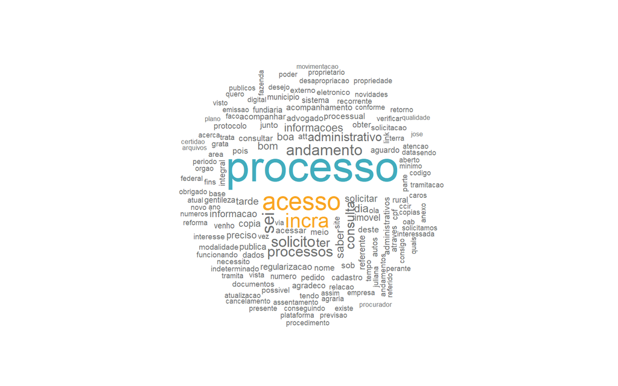

```r
plot_wordcloud_mencao_lgpd(lgpd, "INCRA – Instituto Nacional de Colonização e Reforma Agrária")
```

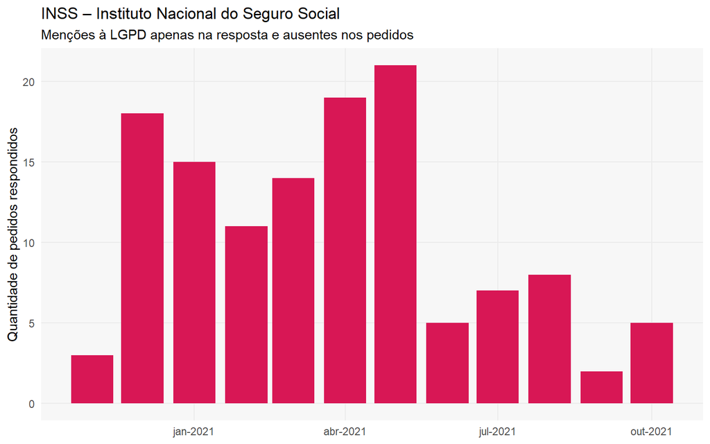

```r
plot_historico_mencao_lgpd(lgpd, "INSS – Instituto Nacional do Seguro Social")
```

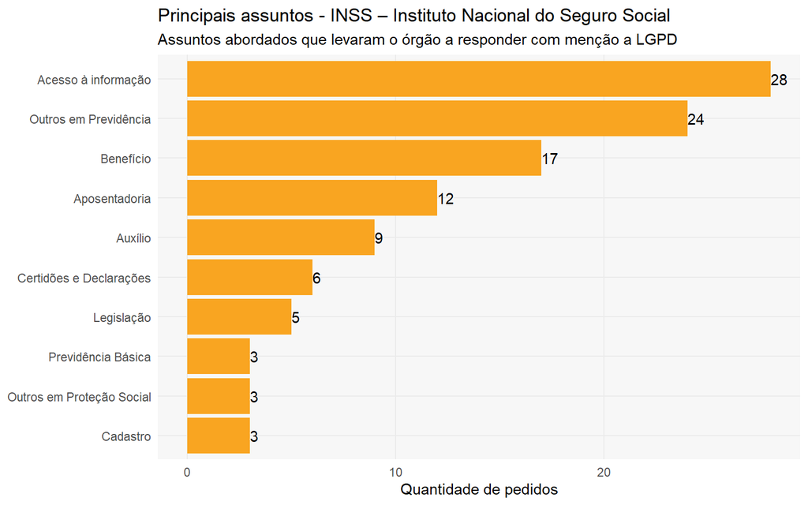

```r
plot_assuntos_mencao_lgpd(lgpd, "INSS – Instituto Nacional do Seguro Social")
```

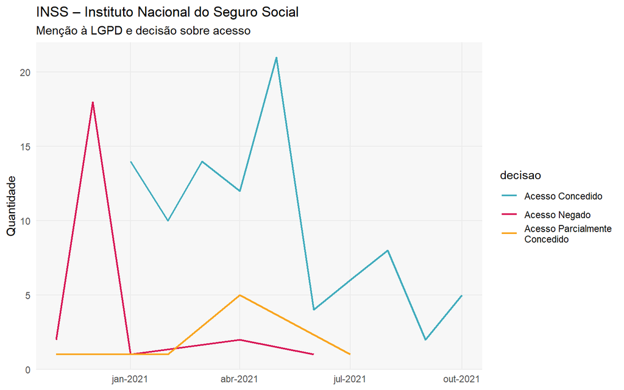

```r
plot_decisoes_mencao_lgpd(lgpd, "INSS – Instituto Nacional do Seguro Social")
```

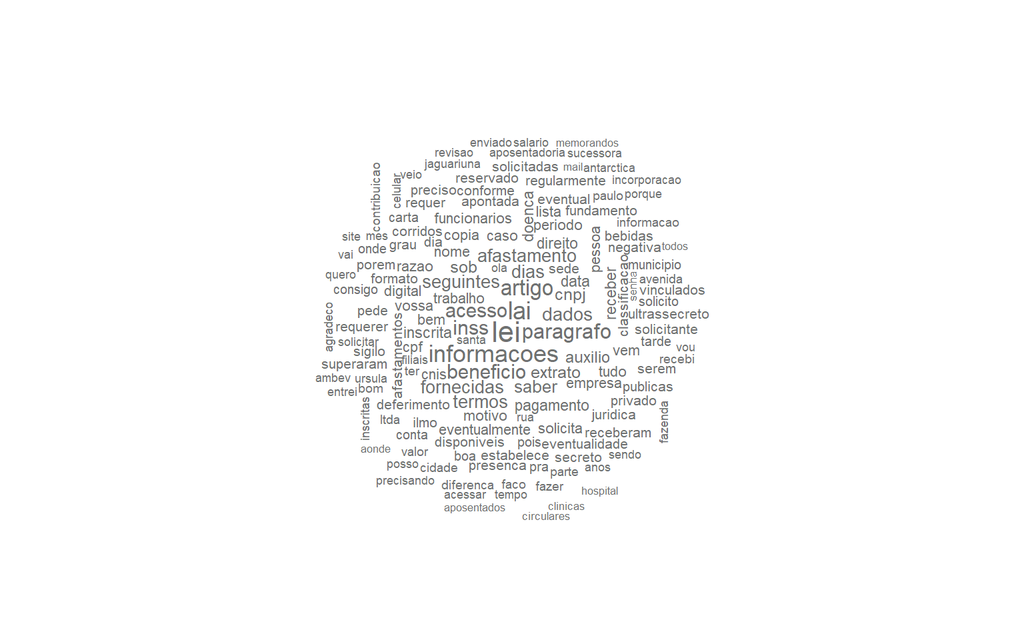

```r
plot_wordcloud_mencao_lgpd(lgpd, "INSS – Instituto Nacional do Seguro Social")
```

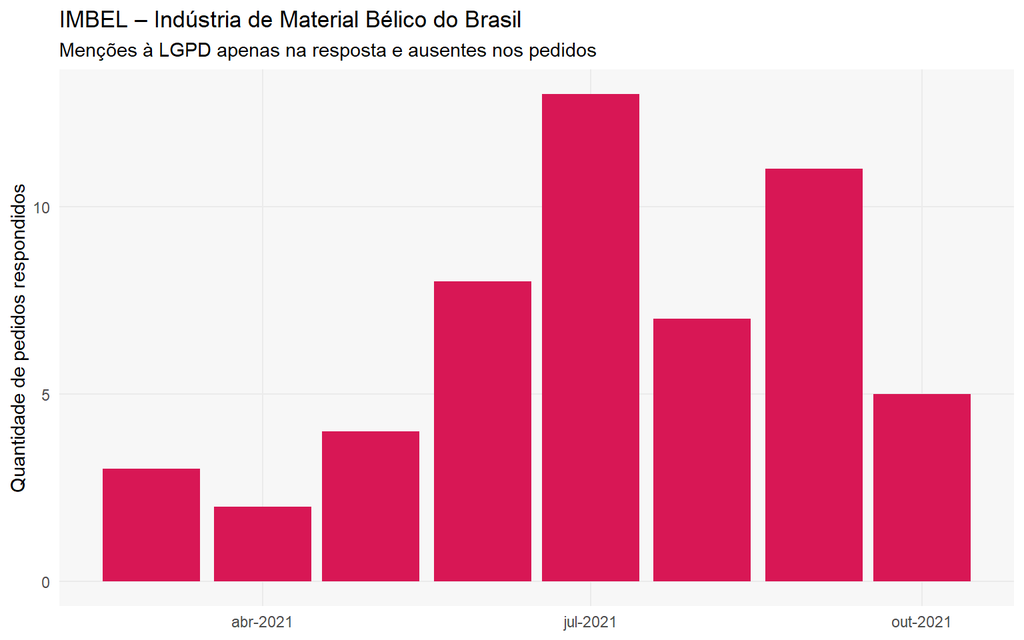

```r
plot_historico_mencao_lgpd(lgpd, "IMBEL – Indústria de Material Bélico do Brasil")
```

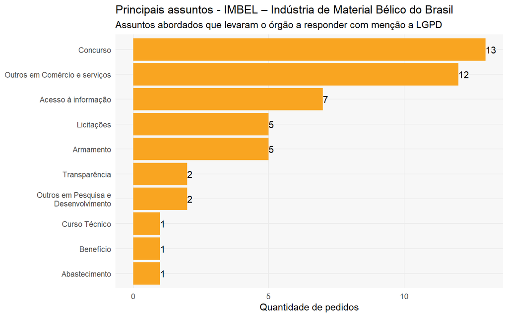

```r
plot_assuntos_mencao_lgpd(lgpd, "IMBEL – Indústria de Material Bélico do Brasil")
```

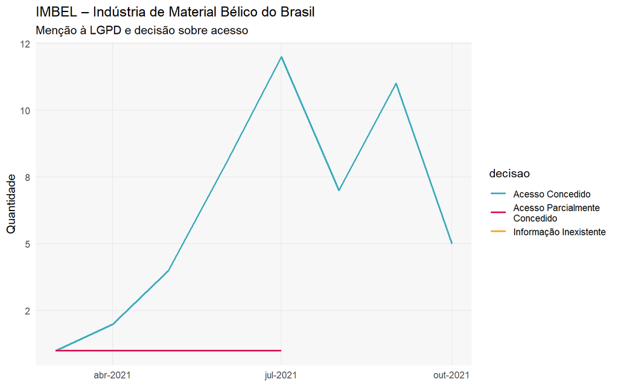

```r
plot_decisoes_mencao_lgpd(lgpd, "IMBEL – Indústria de Material Bélico do Brasil")
```

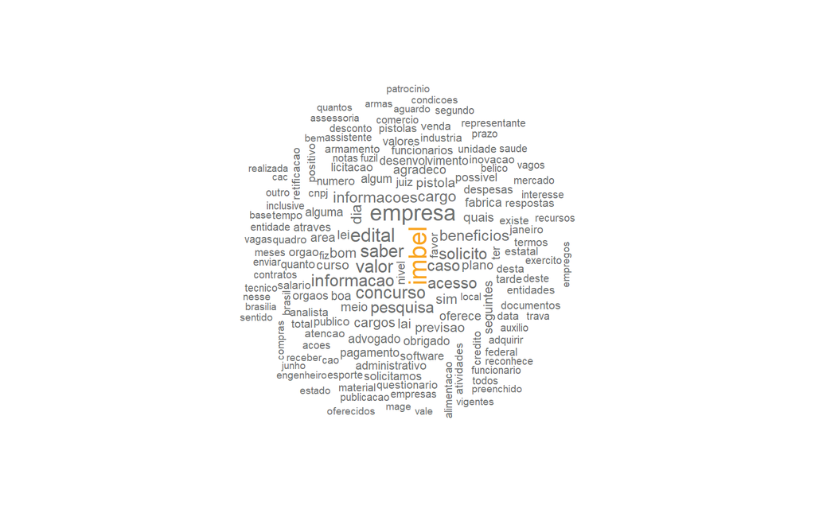

```r
plot_wordcloud_mencao_lgpd(lgpd, "IMBEL – Indústria de Material Bélico do Brasil")
```

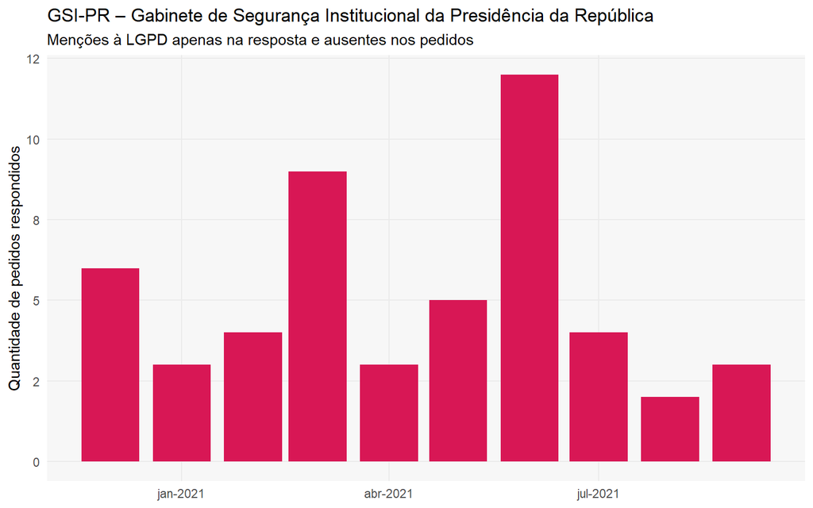

```r
plot_historico_mencao_lgpd(lgpd, "GSI-PR – Gabinete de Segurança Institucional da Presidência da República")
```

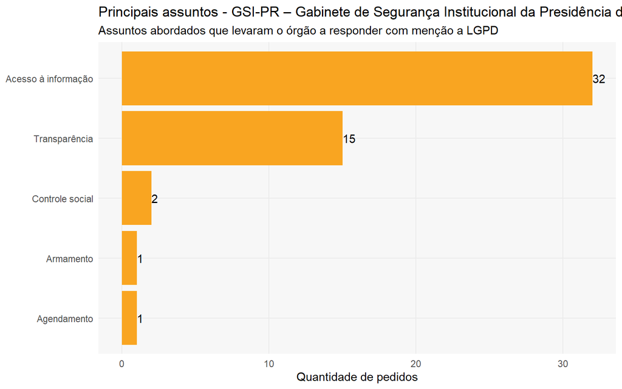

```r
plot_assuntos_mencao_lgpd(lgpd, "GSI-PR – Gabinete de Segurança Institucional da Presidência da República")
```

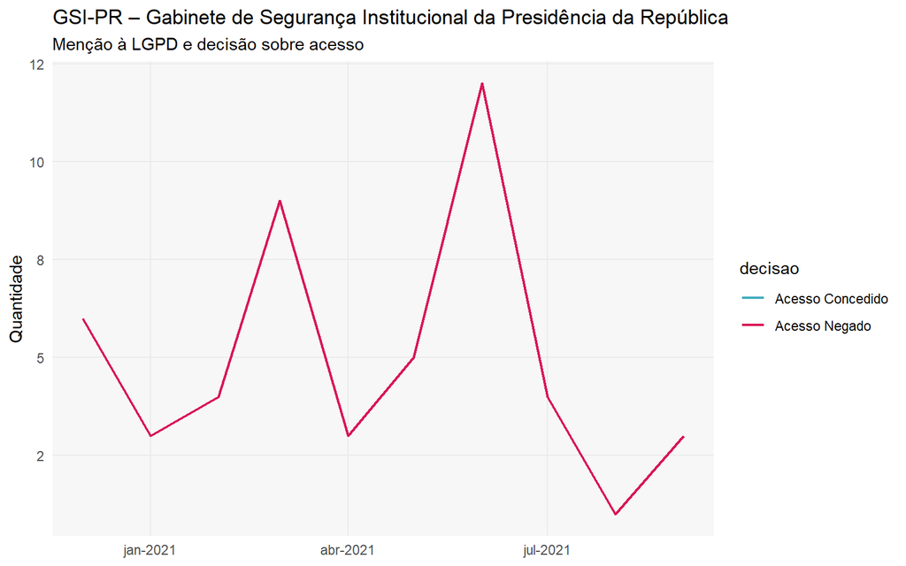

```r
plot_decisoes_mencao_lgpd(lgpd, "GSI-PR – Gabinete de Segurança Institucional da Presidência da República")
```

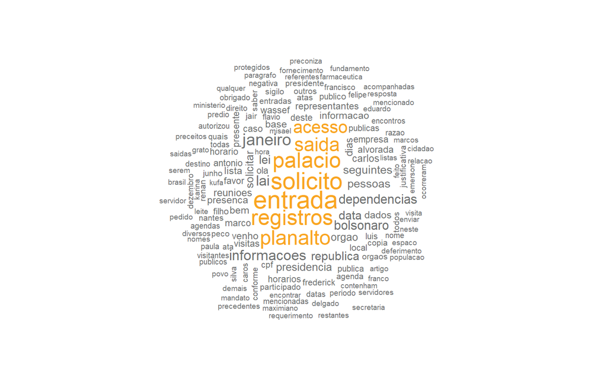

```r
plot_wordcloud_mencao_lgpd(lgpd, "GSI-PR – Gabinete de Segurança Institucional da Presidência da República")
```

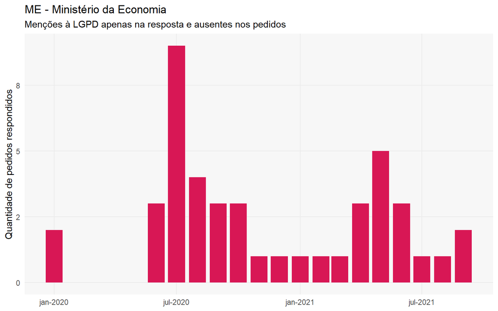

```r
plot_historico_mencao_lgpd(lgpd, "ME - Ministério da Economia")
```

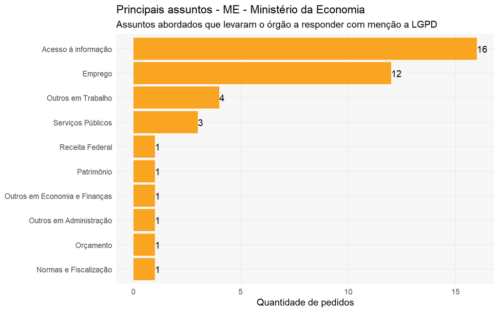

```r
plot_assuntos_mencao_lgpd(lgpd, "ME - Ministério da Economia")
```

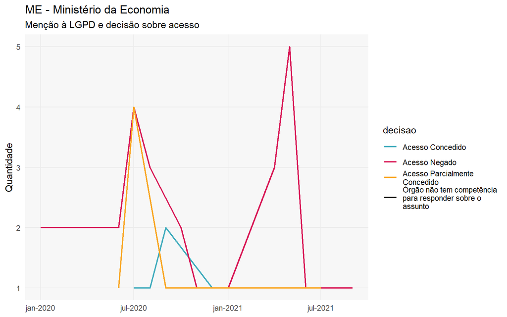

```r
plot_decisoes_mencao_lgpd(lgpd, "ME - Ministério da Economia")
```

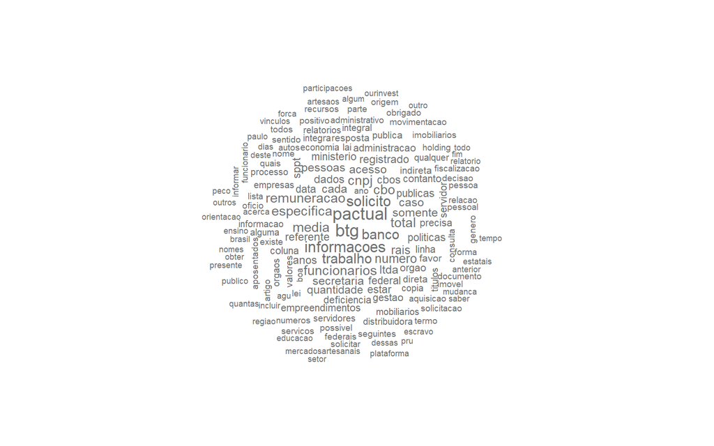

```r
plot_wordcloud_mencao_lgpd(lgpd, "ME - Ministério da Economia")
```

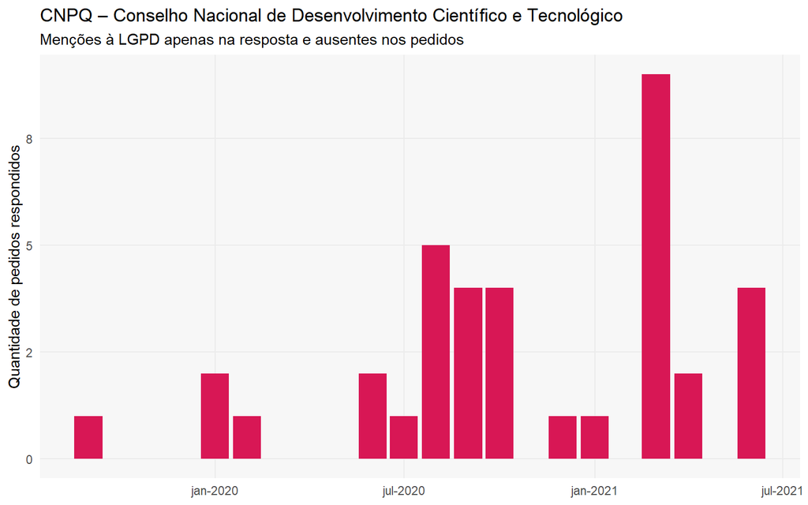

```r
plot_historico_mencao_lgpd(lgpd, "CNPQ – Conselho Nacional de Desenvolvimento Científico e Tecnológico")
```

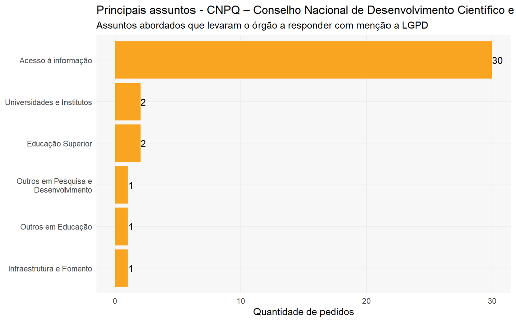

```r
plot_assuntos_mencao_lgpd(lgpd, "CNPQ – Conselho Nacional de Desenvolvimento Científico e Tecnológico")
```

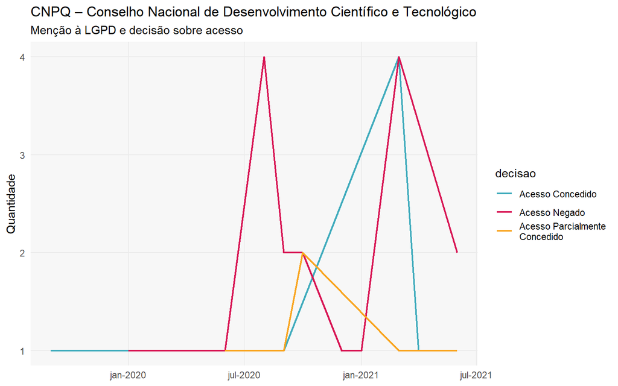

```r
plot_decisoes_mencao_lgpd(lgpd, "CNPQ – Conselho Nacional de Desenvolvimento Científico e Tecnológico")
```

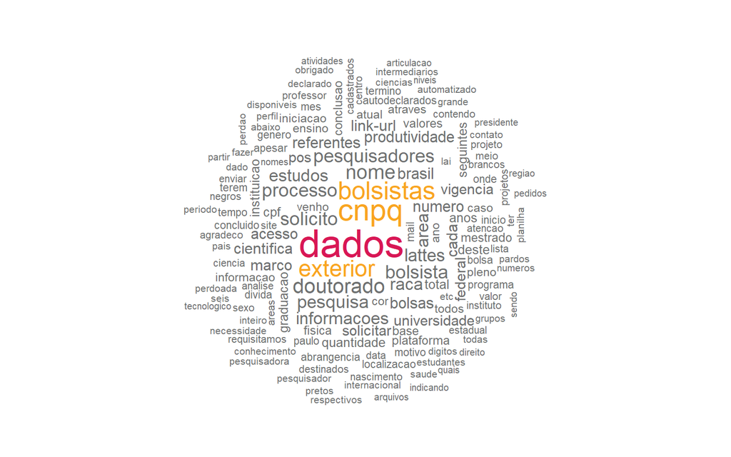

```r
plot_wordcloud_mencao_lgpd(lgpd, "CNPQ – Conselho Nacional de Desenvolvimento Científico e Tecnológico")
```

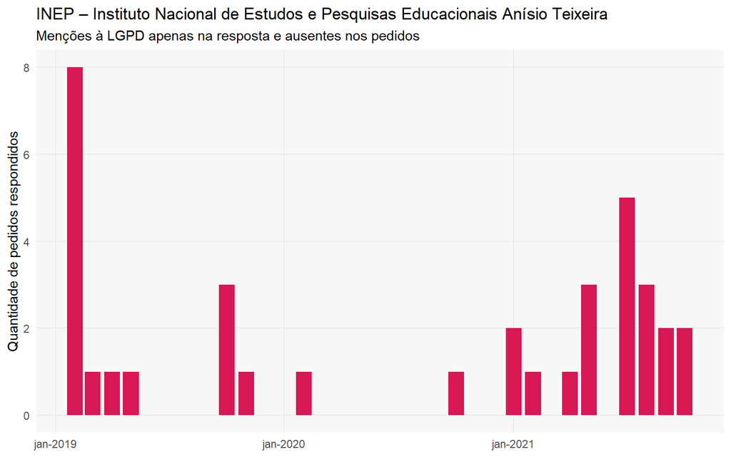

```r
plot_historico_mencao_lgpd(lgpd, "INEP – Instituto Nacional de Estudos e Pesquisas Educacionais Anísio Teixeira")
```

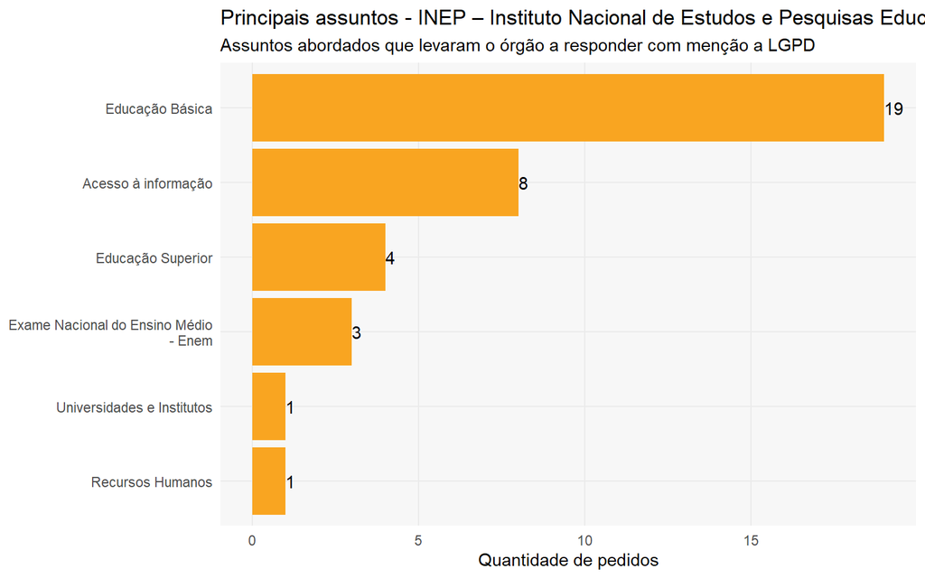

```r
plot_assuntos_mencao_lgpd(lgpd, "INEP – Instituto Nacional de Estudos e Pesquisas Educacionais Anísio Teixeira")
```

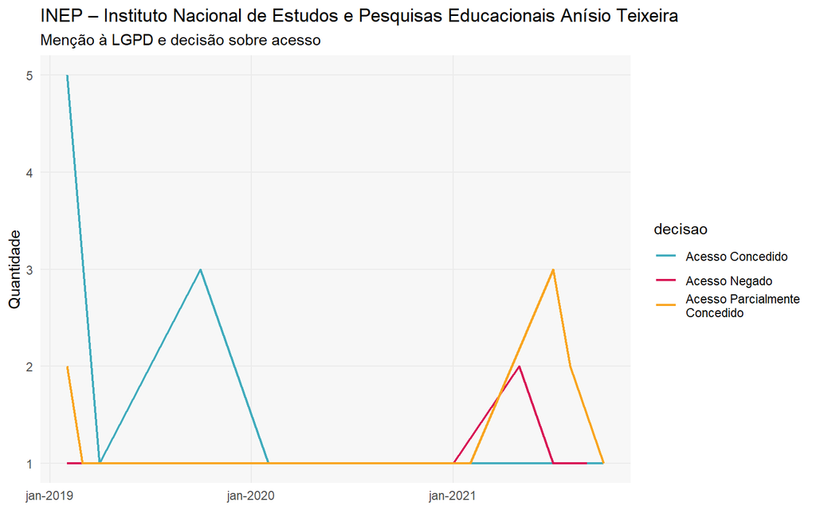

```r
plot_decisoes_mencao_lgpd(lgpd, "INEP – Instituto Nacional de Estudos e Pesquisas Educacionais Anísio Teixeira")
```

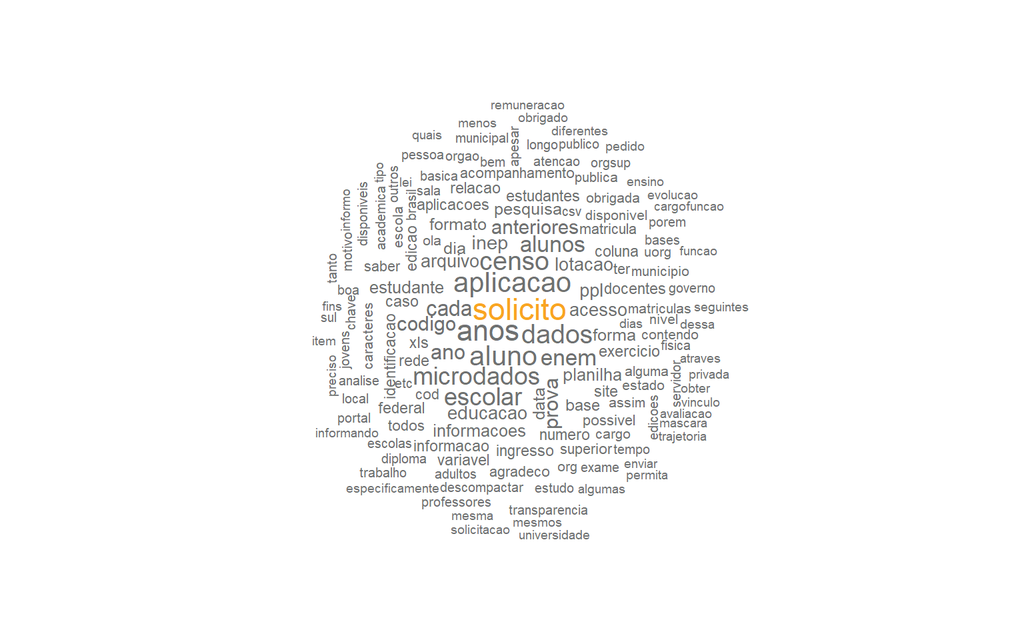

```r
plot_wordcloud_mencao_lgpd(lgpd, "INEP – Instituto Nacional de Estudos e Pesquisas Educacionais Anísio Teixeira")
```

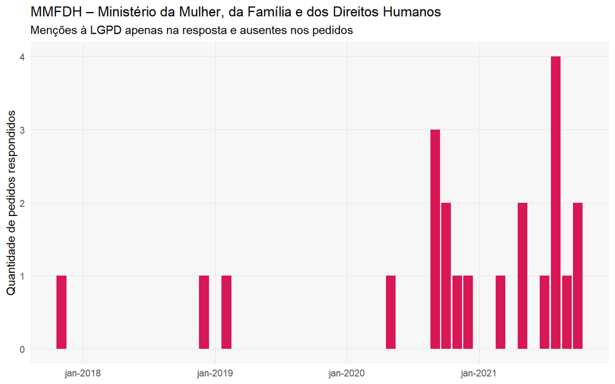

```r
plot_historico_mencao_lgpd(lgpd, "MMFDH – Ministério da Mulher, da Família e dos Direitos Humanos")
```

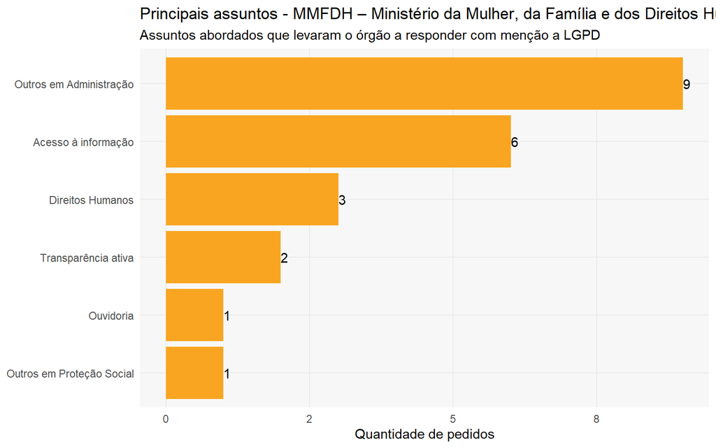

```r
plot_assuntos_mencao_lgpd(lgpd, "MMFDH – Ministério da Mulher, da Família e dos Direitos Humanos")
```

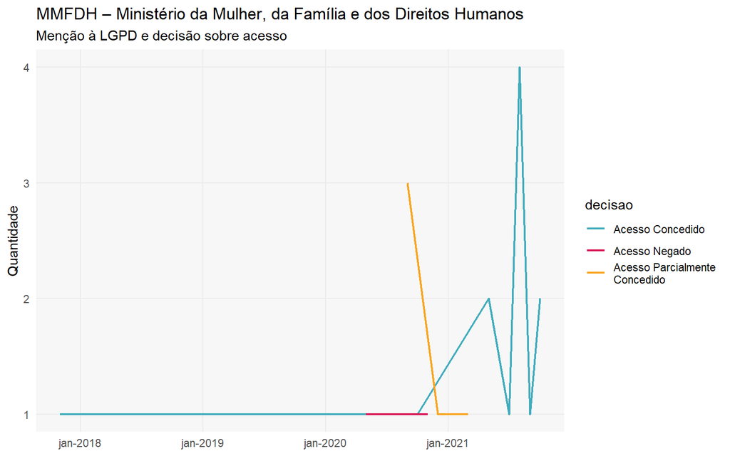

```r
plot_decisoes_mencao_lgpd(lgpd, "MMFDH – Ministério da Mulher, da Família e dos Direitos Humanos")
```

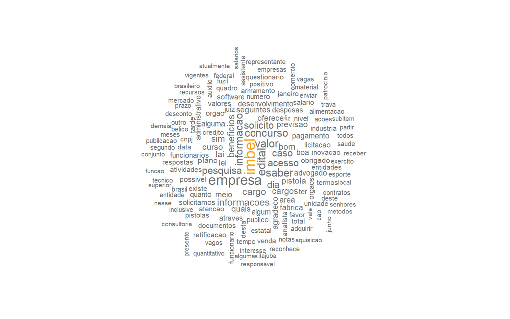

```r
plot_wordcloud_mencao_lgpd(lgpd, "IMBEL – Indústria de Material Bélico do Brasil")
```

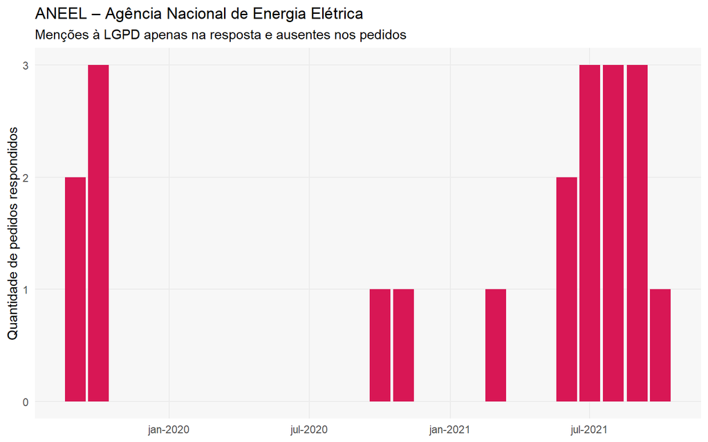

```r
plot_historico_mencao_lgpd(lgpd, "ANEEL – Agência Nacional de Energia Elétrica")
```

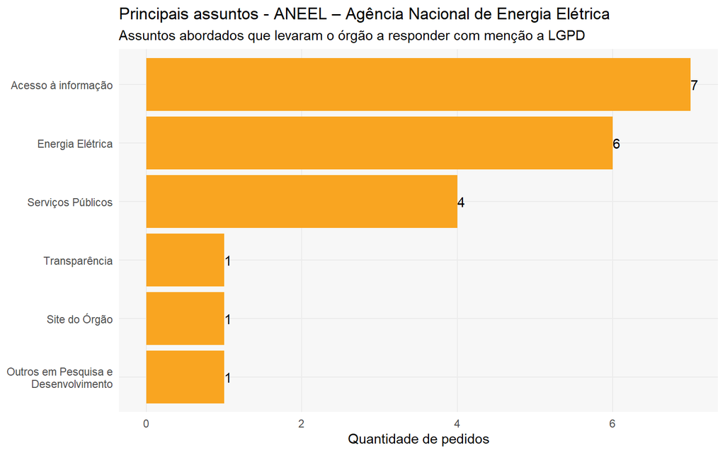

```r
plot_assuntos_mencao_lgpd(lgpd, "ANEEL – Agência Nacional de Energia Elétrica")
```

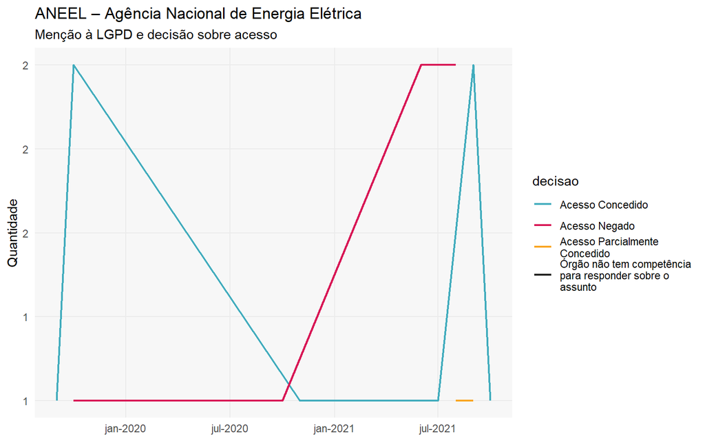

```r
plot_decisoes_mencao_lgpd(lgpd, "ANEEL – Agência Nacional de Energia Elétrica")
```

[figure not shown]

```r
plot_wordcloud_mencao_lgpd(lgpd, "MMFDH – Ministério da Mulher, da Família e dos Direitos Humanos")
```

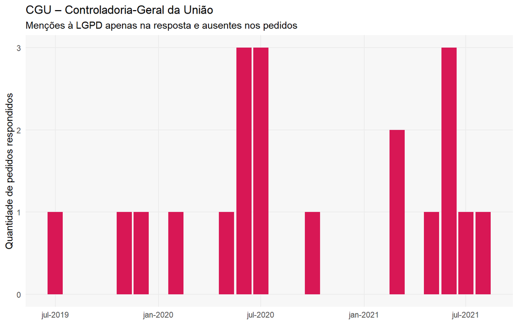

```r
plot_historico_mencao_lgpd(lgpd, "CGU – Controladoria-Geral da União")
```

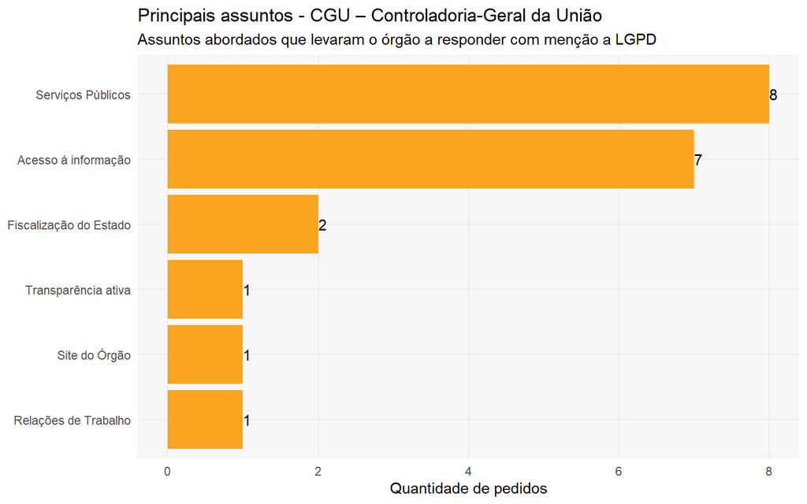

```r
plot_assuntos_mencao_lgpd(lgpd, "CGU – Controladoria-Geral da União")
```

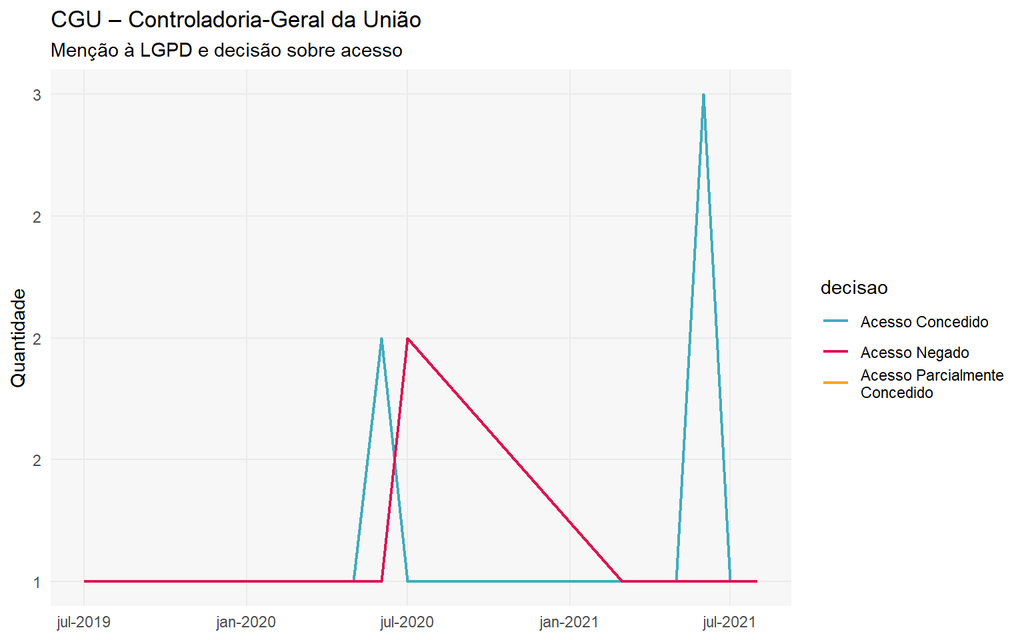

```r
plot_decisoes_mencao_lgpd(lgpd, "CGU – Controladoria-Geral da União")
```

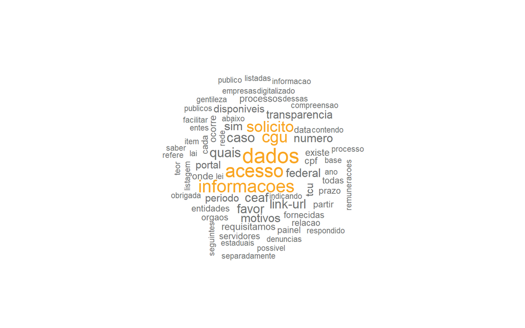

```r
plot_wordcloud_mencao_lgpd(lgpd, "CGU – Controladoria-Geral da União")
```

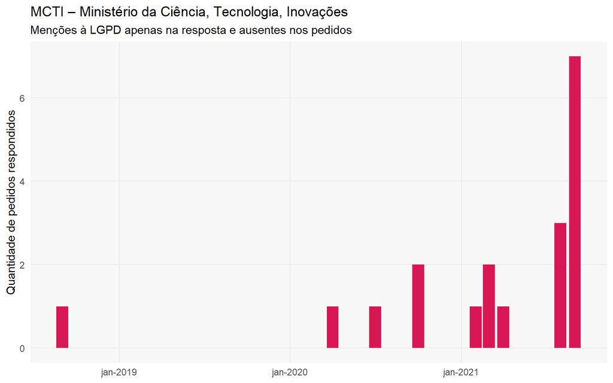

```r
plot_historico_mencao_lgpd(lgpd, "MCTI – Ministério da Ciência, Tecnologia, Inovações")
```

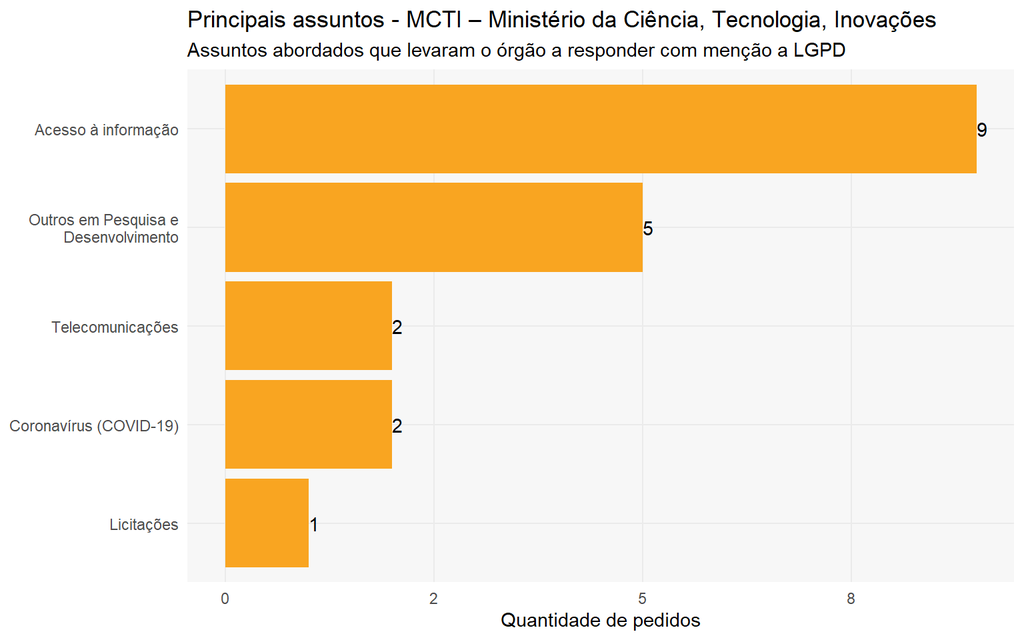

```r
plot_assuntos_mencao_lgpd(lgpd, "MCTI – Ministério da Ciência, Tecnologia, Inovações")
```

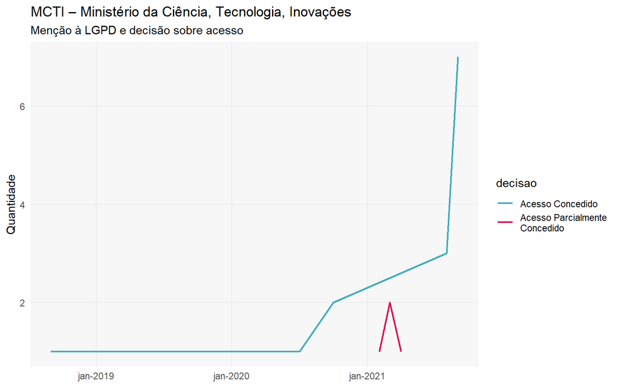

```r
plot_decisoes_mencao_lgpd(lgpd, "MCTI – Ministério da Ciência, Tecnologia, Inovações")
```

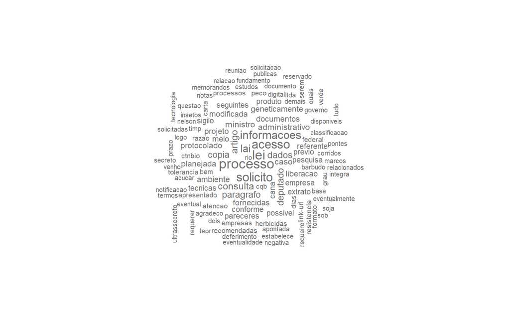

```r
plot_wordcloud_mencao_lgpd(lgpd, "MCTI – Ministério da Ciência, Tecnologia, Inovações")
```

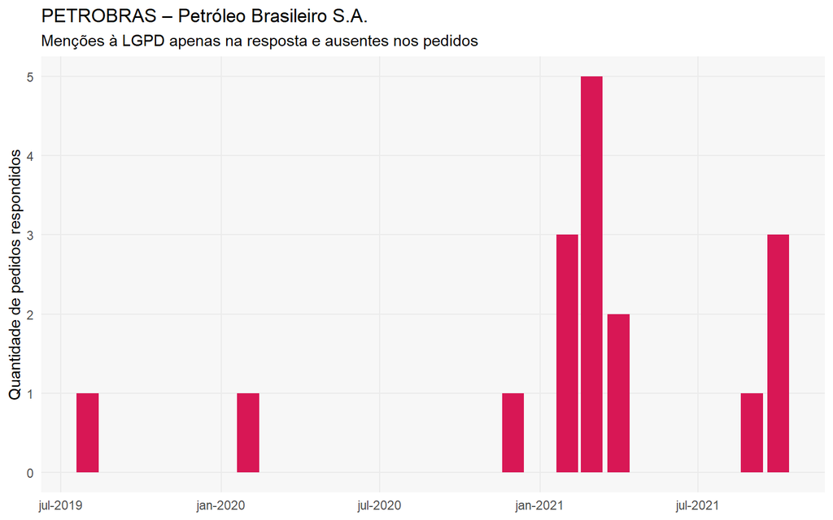

```r
plot_historico_mencao_lgpd(lgpd, "PETROBRAS – Petróleo Brasileiro S.A.")
```

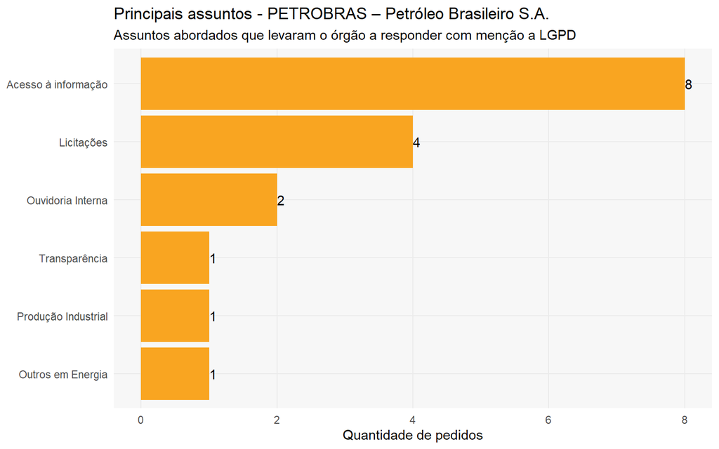

```r
plot_assuntos_mencao_lgpd(lgpd, "PETROBRAS – Petróleo Brasileiro S.A.")
```

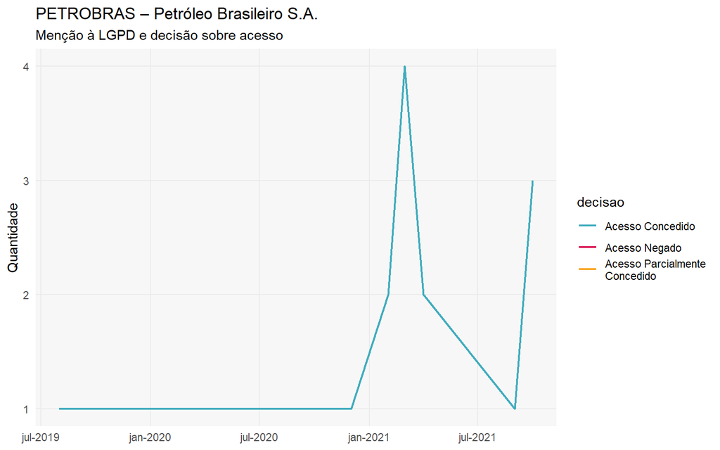

```r
plot_decisoes_mencao_lgpd(lgpd, "PETROBRAS – Petróleo Brasileiro S.A.")
```

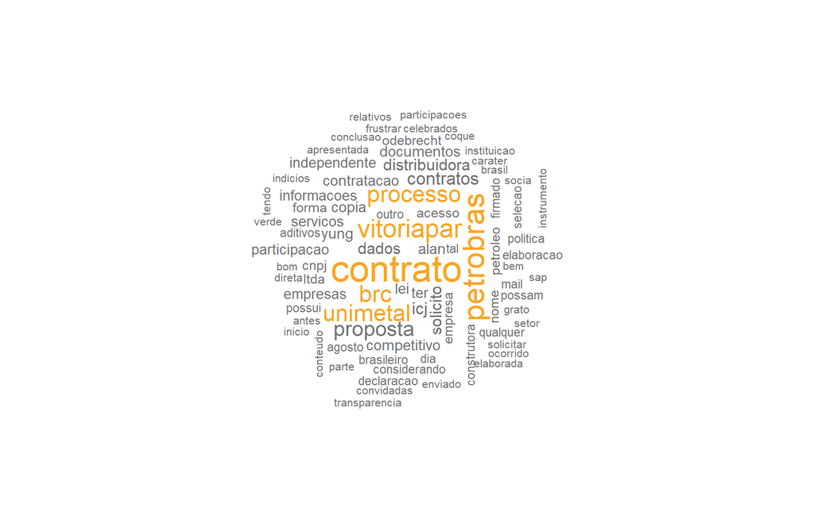

```r
plot_wordcloud_mencao_lgpd(lgpd, "PETROBRAS – Petróleo Brasileiro S.A.")
```

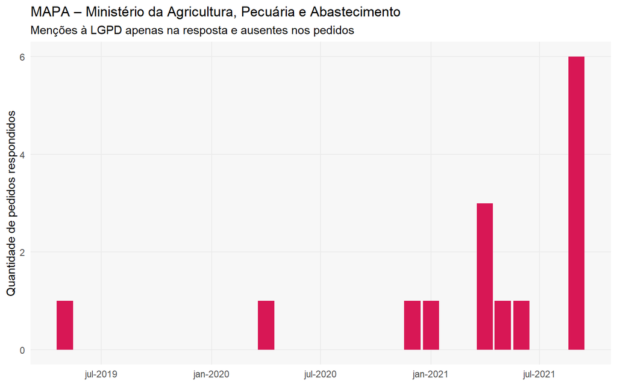

```r
plot_historico_mencao_lgpd(lgpd, "MAPA – Ministério da Agricultura, Pecuária e Abastecimento")
```

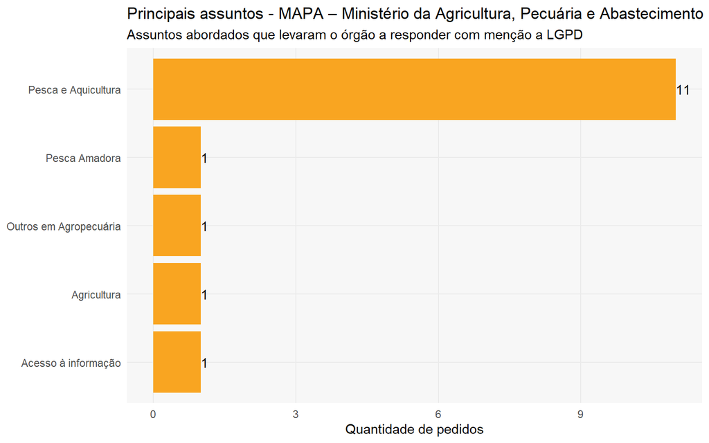

```r
plot_assuntos_mencao_lgpd(lgpd, "MAPA – Ministério da Agricultura, Pecuária e Abastecimento")
```

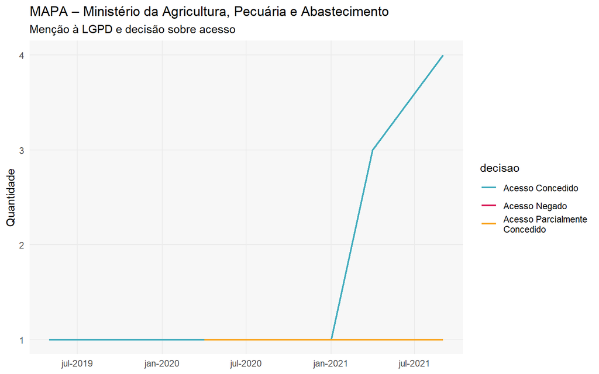

```r
plot_decisoes_mencao_lgpd(lgpd, "MAPA – Ministério da Agricultura, Pecuária e Abastecimento")
```